# Plot Lasagna

### geoms

Different types of plots are called geoms. One geom could be a barplot, a boxplot, a histogram … you name it. For example, we could do a boxplot with `geom_boxplot`. We can add different layers to our lasagne with a `+`.

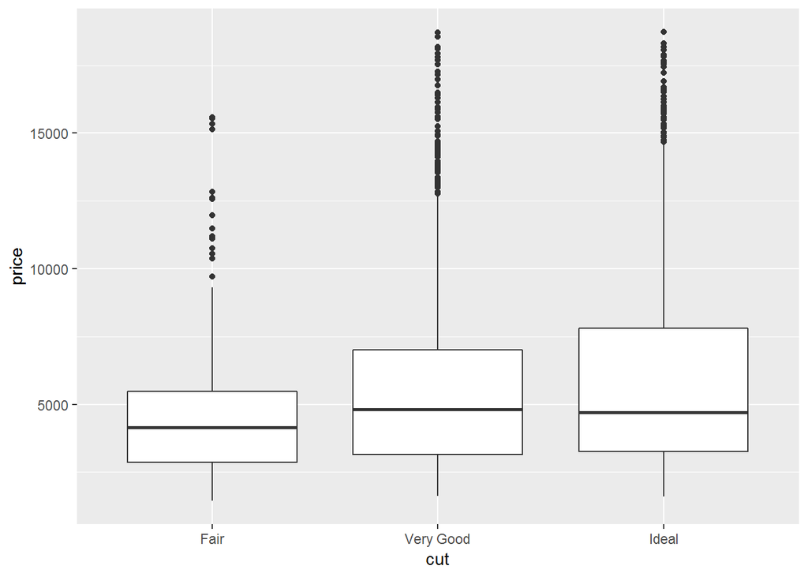

```r
diamonds_small %>%
  ggplot(aes(x = cut, y = price)) +
  geom_boxplot()
```

Of course, we’d like to have some colour and stuff. We can specify them using aesthetics - but this time, they’re sort of “global” aesthetics that don’t have anything to do with the properties of our data. Hence, we don’t wrap them in `aes` to map our data, but specify them outside of it.

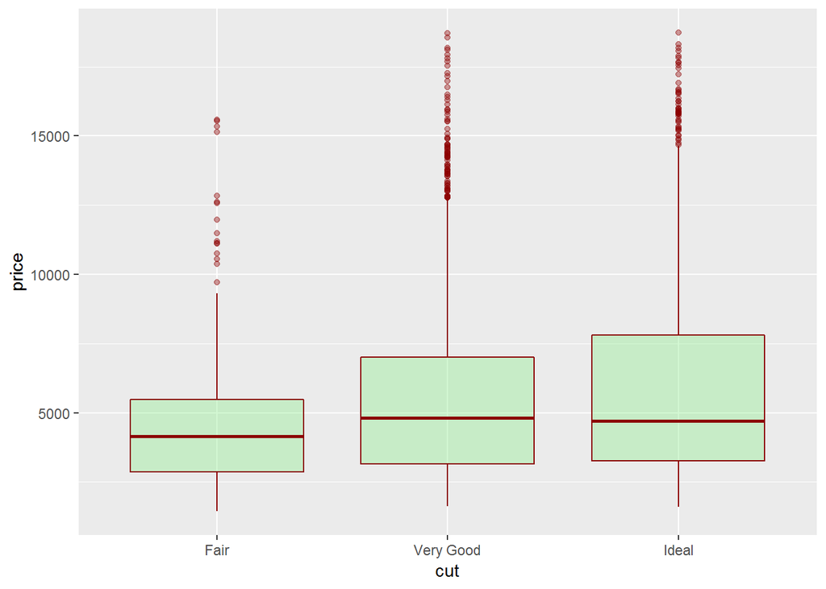

```r
diamonds_small %>%
  ggplot(aes(x = cut, y = price)) +
  geom_boxplot(colour = "dark red", fill = "light green", alpha = .4)
```

We could very well put the aesthetics in `aes` into `geom_col`, we don’t need to; `ggplot` will just take the aesthetics from `ggplot`. The interesting point is that aesthetics work as “global” aesthetics or as mapping. For example, we can map groups in our data to the colour of our plot. That means we can easily divide our diamonds by the clarity.

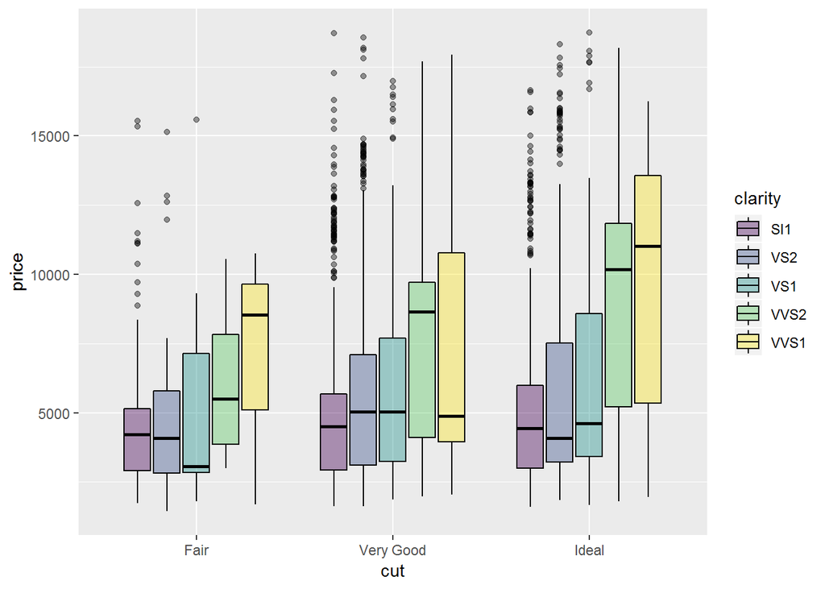

```r
diamonds_small %>%
  ggplot(aes(x = cut, y = price, fill = clarity)) +
  geom_boxplot(colour = "black", alpha = .4)
```

### Customisation

`ggplot` has picked some colours to fill the bars with, but we can easily specify our own colours using either their names our hex code. We just add another layer to our lasagna.

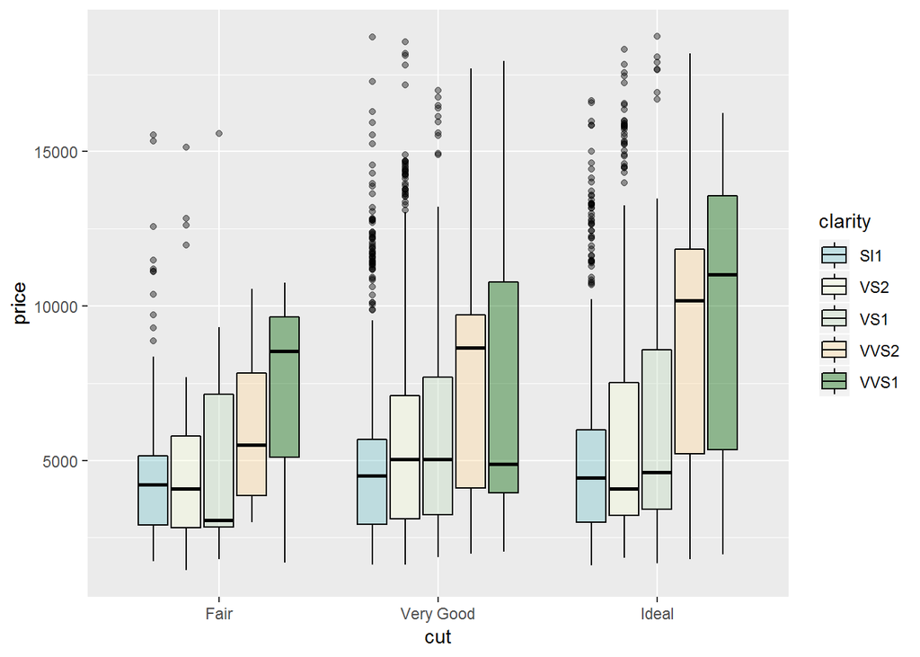

```r
diamonds_small %>%
  ggplot(aes(x = cut, y = price, fill = clarity)) +
  geom_boxplot(colour = "black", alpha = .4) +
  scale_fill_manual(values = c("cadetblue3", "#F4FDD9", "#C3DBC0", "#FFDAA0",
                               "dark green"))
```

With the same logic, we could custom the breaks of our y-axis:

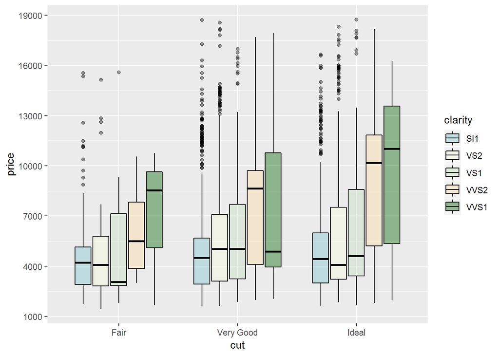

```r
diamonds_small %>%
  ggplot(aes(x = cut, y = price, fill = clarity)) +
  geom_boxplot(colour = "black", alpha = .4) +
  scale_fill_manual(values = c("cadetblue3", "#F4FDD9", "#C3DBC0", "#FFDAA0",
                               "dark green")) +
  scale_y_continuous(breaks = seq(1000, 19000, 3000))
```

Why not use different titles?

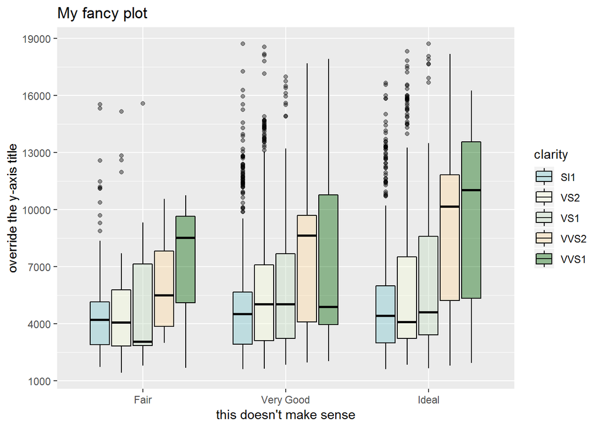

```r
diamonds_small %>%
  ggplot(aes(x = cut, y = price, fill = clarity)) +
  geom_boxplot(colour = "black", alpha = .4) +
  scale_fill_manual(values = c("cadetblue3", "#F4FDD9", "#C3DBC0", "#FFDAA0",
                               "dark green")) +
  scale_y_continuous(breaks = seq(1000, 19000, 3000)) +
  labs(title = "My fancy plot", y = "override the y-axis title",
       x = "this doesn't make sense")
```

With `theme()`, we can change a lot about our plots appearance. Check out these changes:

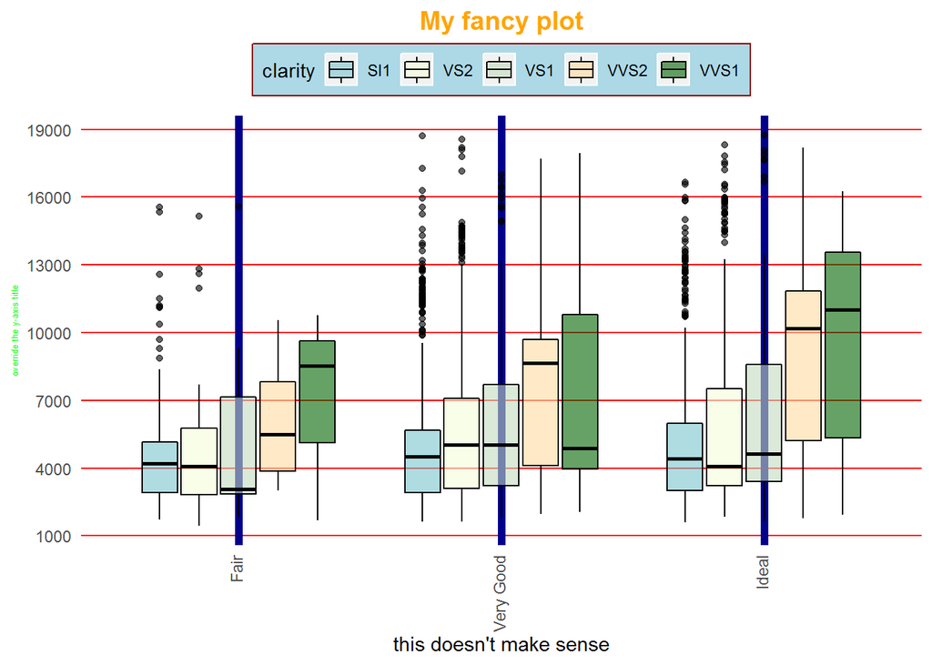

```r
diamonds_small %>%
  ggplot(aes(x = cut, y = price, fill = clarity)) +
  geom_boxplot(colour = "black", alpha = .6) +
  scale_fill_manual(values = c("cadetblue3", "#F4FDD9", "#C3DBC0", "#FFDAA0",
                               "dark green")) +
  scale_y_continuous(breaks = seq(1000, 19000, 3000)) +
  labs(title = "My fancy plot", y = "override the y-axis title",
       x = "this doesn't make sense") +
  theme(legend.position = "top",
        legend.background = element_rect(fill = "light blue", colour = "dark red"),
        plot.title = element_text(face = "bold", colour = "orange", size = 14,
                                  hjust = .5),
        axis.text.x = element_text(angle = 90, hjust = 1, vjust = .3),
        axis.ticks = element_blank(),
        axis.title.y = element_text(size = 5, colour = "green"),
        panel.grid.major = element_line(colour = "dark blue", size = 2),
        panel.grid.major.y = element_line(colour = "red", size = .5),
        panel.background = element_blank())
```

### More useful

Having created the ugliest plot lasagna ever, we should probably turn to some more reasonable stuff, like combining different geoms. Let’s have a scatter plot with a regression line in it.

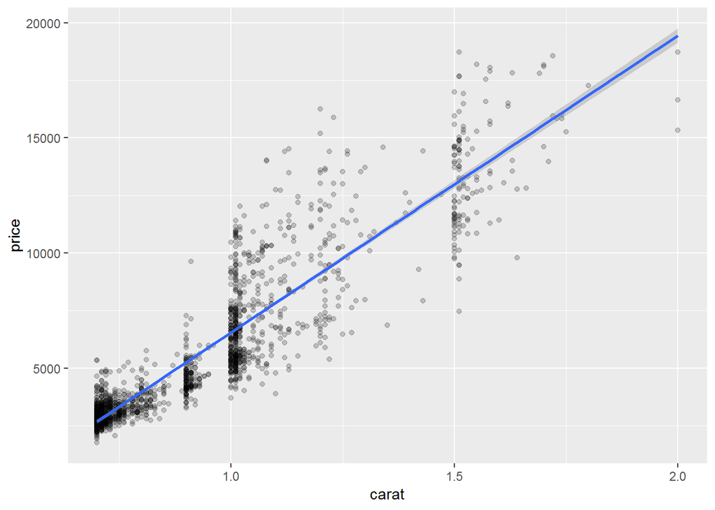

```r
diamonds_small %>%
  filter(color == "E") %>%
  ggplot(aes(x = carat, y = price)) +
  geom_point(alpha = .2, size = 1.5) +
  geom_smooth(method = "lm")
```

Another thing that’s really useful is facets. You can group your plot by one parameter …

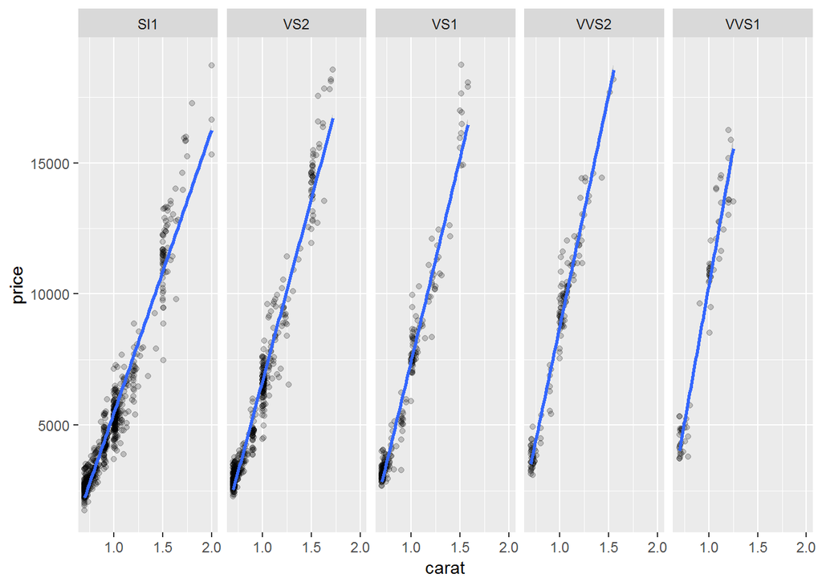

```r
diamonds_small %>%
  filter(color == "E") %>%
  ggplot(aes(x = carat, y = price)) +
  geom_point(alpha = .2, size = 1.5) +
  geom_smooth(method = "lm") +
  facet_grid(~clarity)
```

… or by several ones.

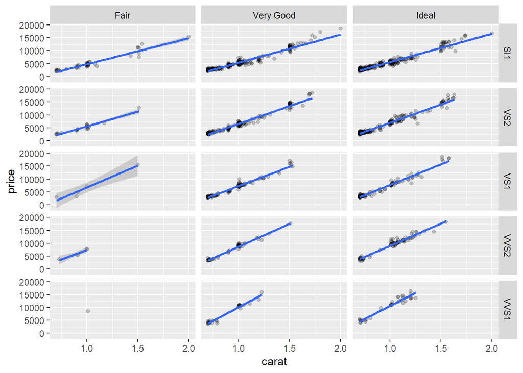

```r
diamonds_small %>%
  filter(color == "E") %>%
  ggplot(aes(x = carat, y = price)) +
  geom_point(alpha = .2, size = 1.5) +
  geom_smooth(method = "lm") +
  facet_grid(clarity ~ cut)
```

### Lowering the bar

What about ordinary bar plots? There are some caveats. First of all, `geom_bar` counts categories and won’t take a y-coordinate.

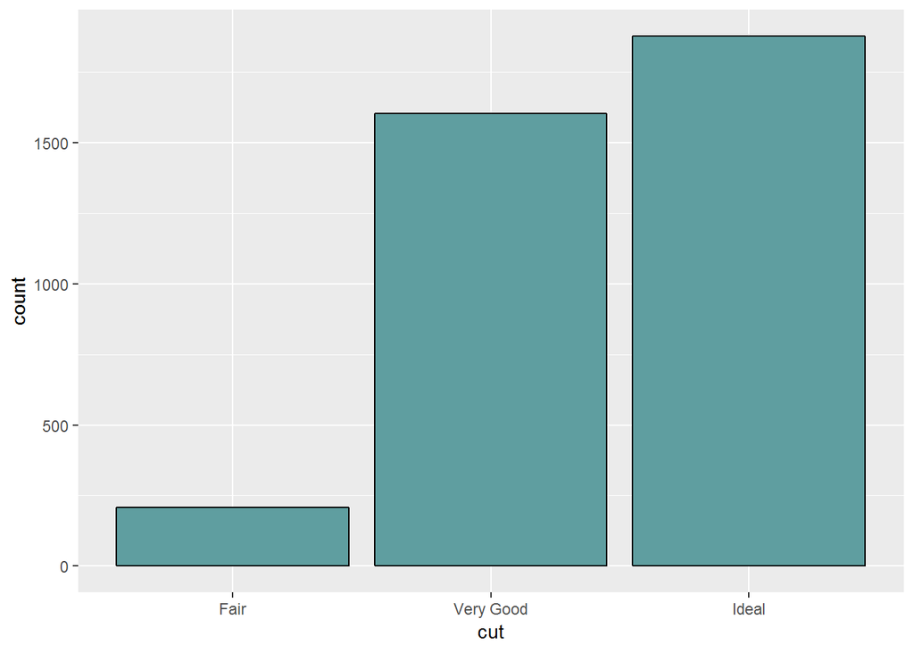

```r
diamonds_small %>%
  ggplot(aes(x = cut)) +
  geom_bar(colour = "black", fill = "cadetblue")
```

Ok, that’s not entirely true. We can switch to proportions with this neat little trick.

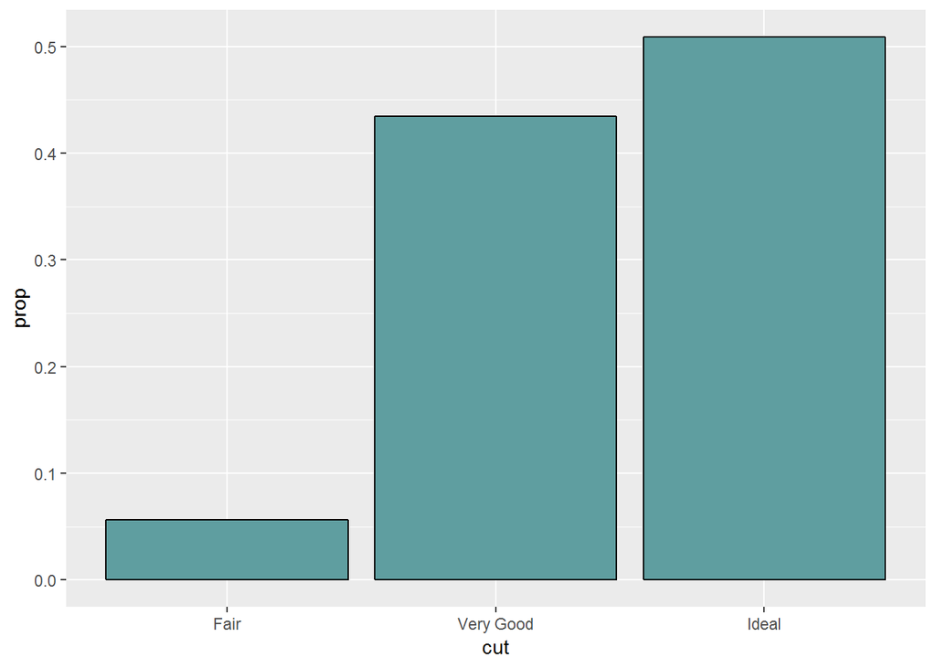

```r
diamonds_small %>%
  ggplot(aes(x = cut, y = ..prop.., group = "dummy")) +
  geom_bar(colour = "black", fill = "cadetblue")
```

And look what happens when we group the data!

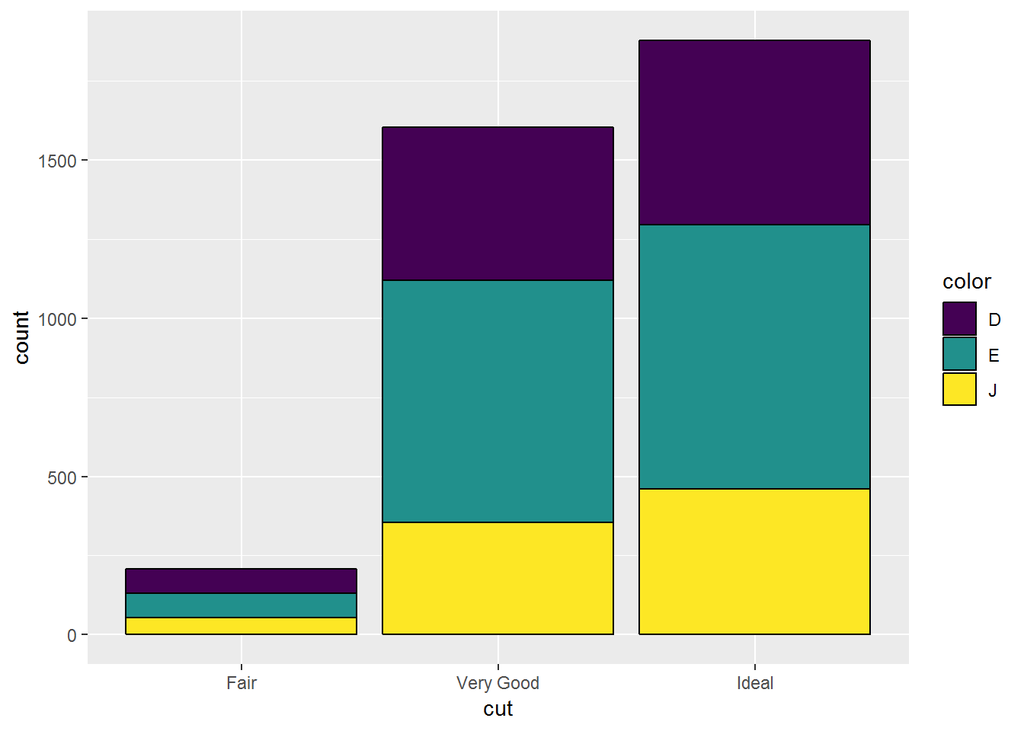

```r
diamonds_small %>%
  ggplot(aes(x = cut)) +
  geom_bar(aes(fill = color), colour = "black")
```

We can change that, though …

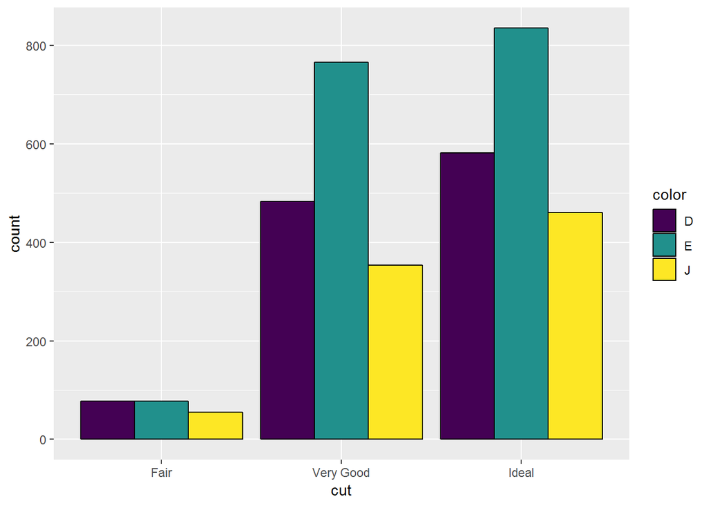

```r
diamonds_small %>%
  ggplot(aes(x = cut)) +
  geom_bar(aes(fill = color), colour = "black", position = "dodge")
```

`geom_col`, on the other hand, takes x- and y-coordinates. But it behaves a bit funny. I filled it in a light blue colour, but the bars appear black and the y-axis seems messed up. In a reduced data set, you could see that the black comes from the outlines of loads of individual bars stacked into each other - because for every pair of cut/price, a bar is drawn - for all the 3689 observations in `diamonds_small`! That’s stupid. We want the mean price per category. not the individual data points.

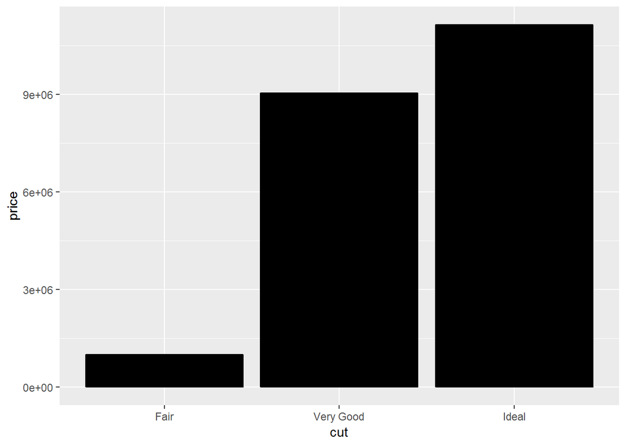

```r
diamonds_small %>%
  ggplot(aes(x = cut, y = price)) +
  geom_col(colour = "black", fill = "light blue")
```

### Stats

Geoms and stats are (actually interchangeable) siblings. We can either manually set up a `data.frame` with means, sd and stuff … or use the existing stats to do just that. By default, `stat_summary` will give us the mean. We specified `"bar"` (`"col"` would work as well) as our geom, because `stat_summary` is by default connected with `geom_pointrange`. Have a look at this [cheat sheet](https://www.rstudio.com/wp-content/uploads/2015/03/ggplot2-cheatsheet.pdf) for different geoms and stats.

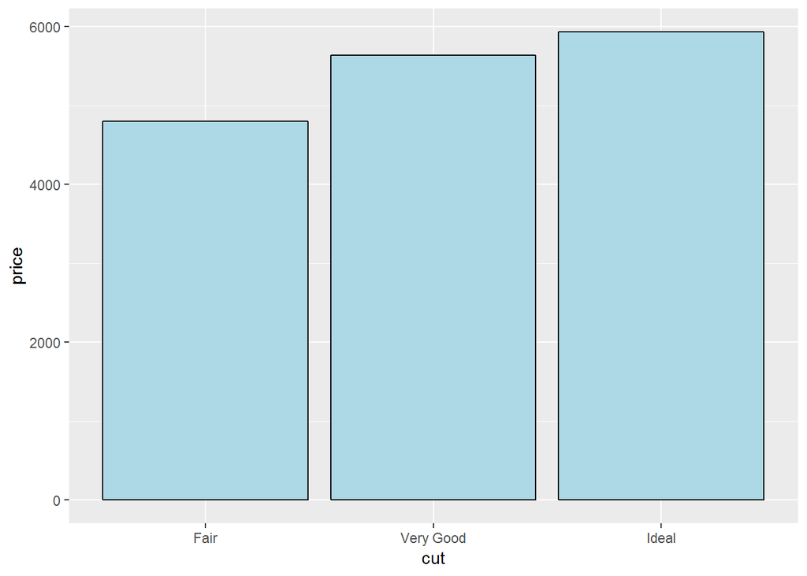

```r
diamonds_small %>%
  ggplot(aes(x = cut, y = price)) +
  stat_summary(colour = "black", fill = "light blue", geom = "bar")
```

That means, we could do it the other way round and use `geom_bar` while specifying `"summary"` for `stat`:

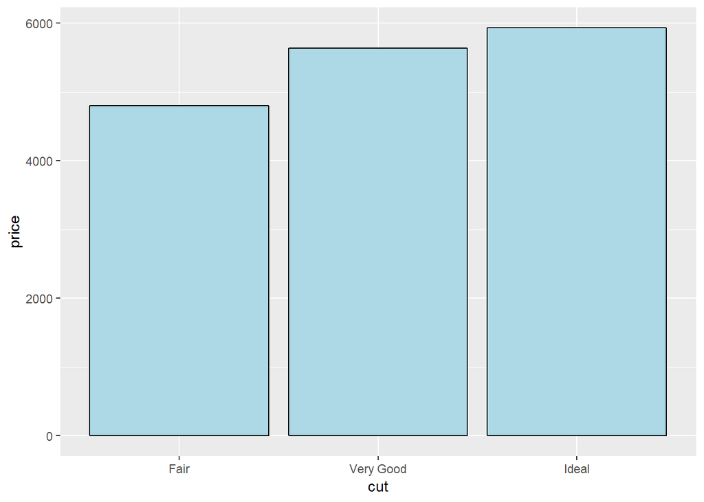

```r
diamonds_small %>%
  ggplot(aes(x = cut, y = price)) +
  geom_bar(colour = "black", fill = "light blue", stat = "summary")
```

You saw that `stats_summary` is usually connected to `geom_pointrange` in a similar fashion, we can produce a bar plot with errorbars:

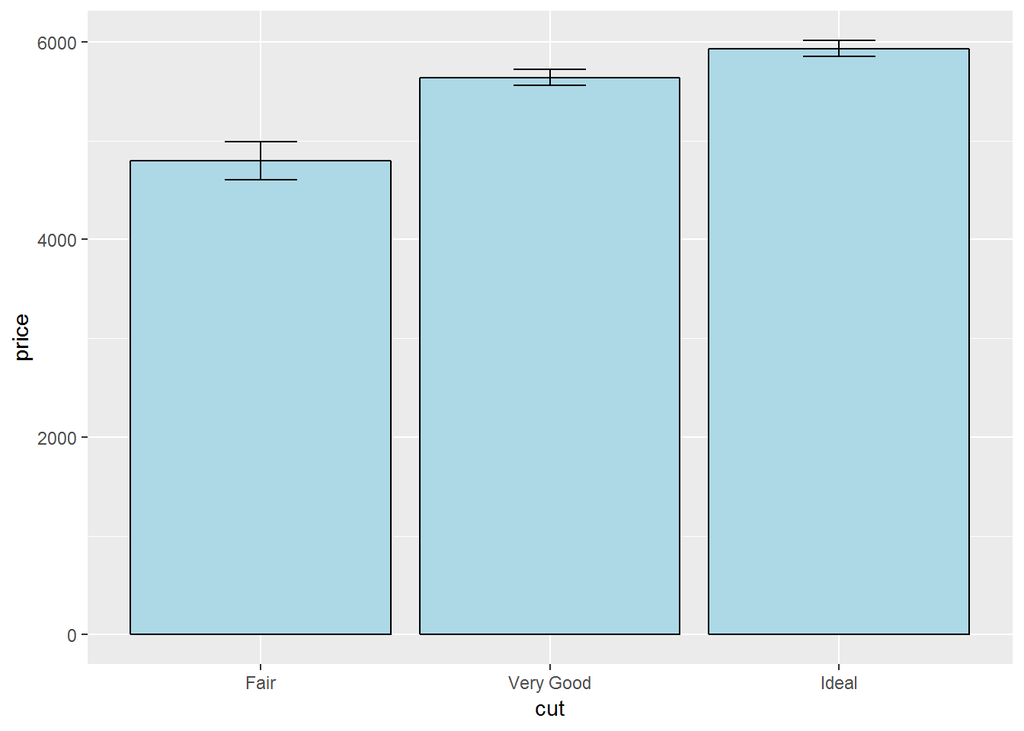

```r
diamonds_small %>%
  ggplot(aes(x = cut, y = price)) +
  geom_bar(colour = "black", fill = "light blue", stat = "summary") +
  geom_errorbar(stat = "summary", width = .25)
```

You could very well have your own values for xmin and ymin of your errorbars. You can also specify the functions used to generate the different values. While, for example, `stat_summary` uses mean and se (`mean_se`) by default, we can change that to the standard deviation.

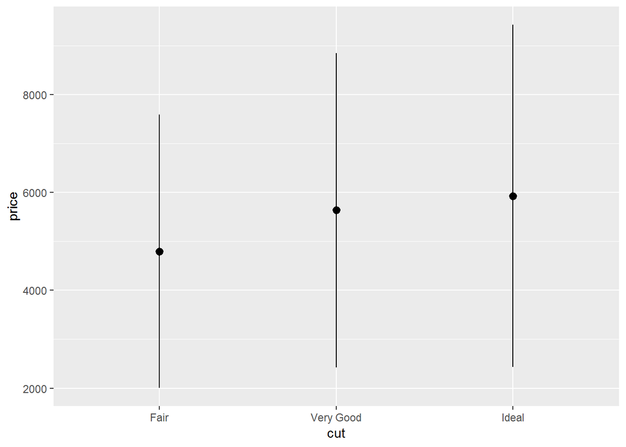

```r
diamonds_small %>%
  ggplot(aes(x = cut, y = price)) +
  stat_summary(fun.y = mean,
               fun.ymax = function(x) mean(x) + sd(x),
               fun.ymin = function(x) mean(x) - sd(x))
```

We can also have a grouped version - something you’d use for an ANOVA or stuff (let’s use the se for this again, though). We need to add another layer to connect the dots with lines. Note that this only works if we group the data using group - only grouping it by colour will cause `ggplot` to complain. We could use only `group`, but then the different lines will not be coloured.

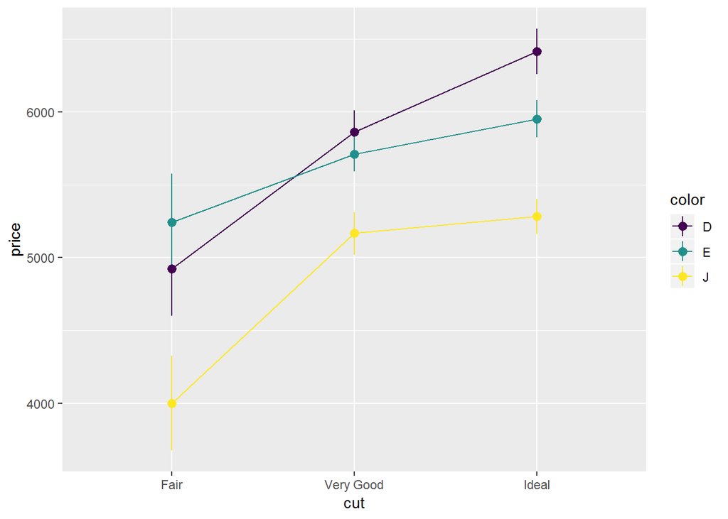

```r
diamonds_small %>%
  ggplot(aes(x = cut, y = price, colour = color, group = color)) +
  stat_summary() +
  stat_summary(fun.y = mean, geom = "line")
```

### Add significance

Want to have these fancy little asterisks in your plots? Check out `ggpubr` (for a detailed blog post, go [here](https://www.r-bloggers.com/add-p-values-and-significance-levels-to-ggplots/))! The default is a Kruskal Wallis test for the overall effect and Wilcoxon Tests for the pairwise comparisons, but we can specify an ANOVA and a t.test (better double check with your results anyways). The pairwise comparisons are already Bonferroni corrected.

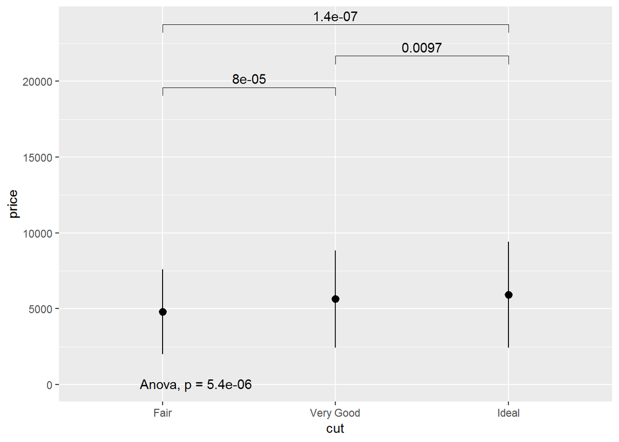

```r
library(ggpubr)
pairwise_comparisons <- list( c("Fair", "Very Good"), c("Very Good", "Ideal"),
                              c("Fair", "Ideal") )

diamonds_small %>%
  ggplot(aes(x = cut, y = price)) +
  stat_summary(fun.y = mean,
               fun.ymax = function(x) mean(x) + sd(x),
               fun.ymin = function(x) mean(x) - sd(x)) +
  stat_compare_means(comparisons = pairwise_comparisons, method = "t.test") +
  stat_compare_means(label.y = 50, method = "anova")
```

Fancy something a bit more minimalistic?

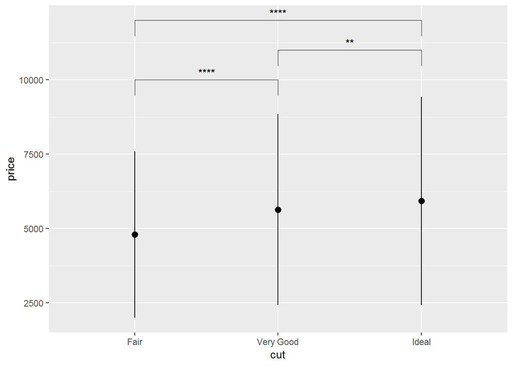

```r
pairwise_comparisons <- list( c("Fair", "Very Good"), c("Very Good", "Ideal"),
                              c("Fair", "Ideal") )

diamonds_small %>%
  ggplot(aes(x = cut, y = price)) +
  stat_summary(fun.y = mean,
               fun.ymax = function(x) mean(x) + sd(x),
               fun.ymin = function(x) mean(x) - sd(x)) +
  stat_compare_means(comparisons = pairwise_comparisons, method = "t.test",
                     label =  "p.signif", label.y = c(10000, 11000, 12000))
```

You can also speficy reference groups, it works for grouped plots as well … possibilities are endless!

### Let’s get wild

There aren’t many occasions where you can reasonably use animations in your plots. Still, it’s good for impressing your peers at conferences or Twitter. There’s much to be said about `gganimate` and getting into all of its functions would be a topic on its own. For now, let’s consider these common examples: We can reveal a plot along its axes (if we want to keep the points we have to give them a group):

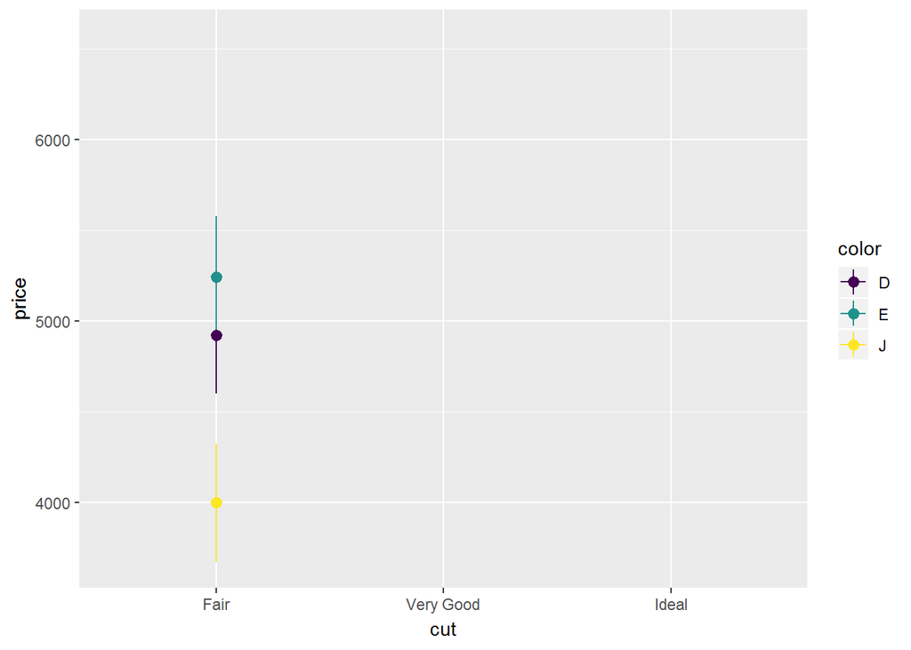

```r
library(gganimate)

diamonds_small %>%
  ggplot(aes(x = cut, y = price, colour = color, group = color)) +
  stat_summary() +
  stat_summary(fun.y = mean, geom = "line") +
  transition_reveal(stat(x))
```

Or we could transition between the different degrees of clarity.

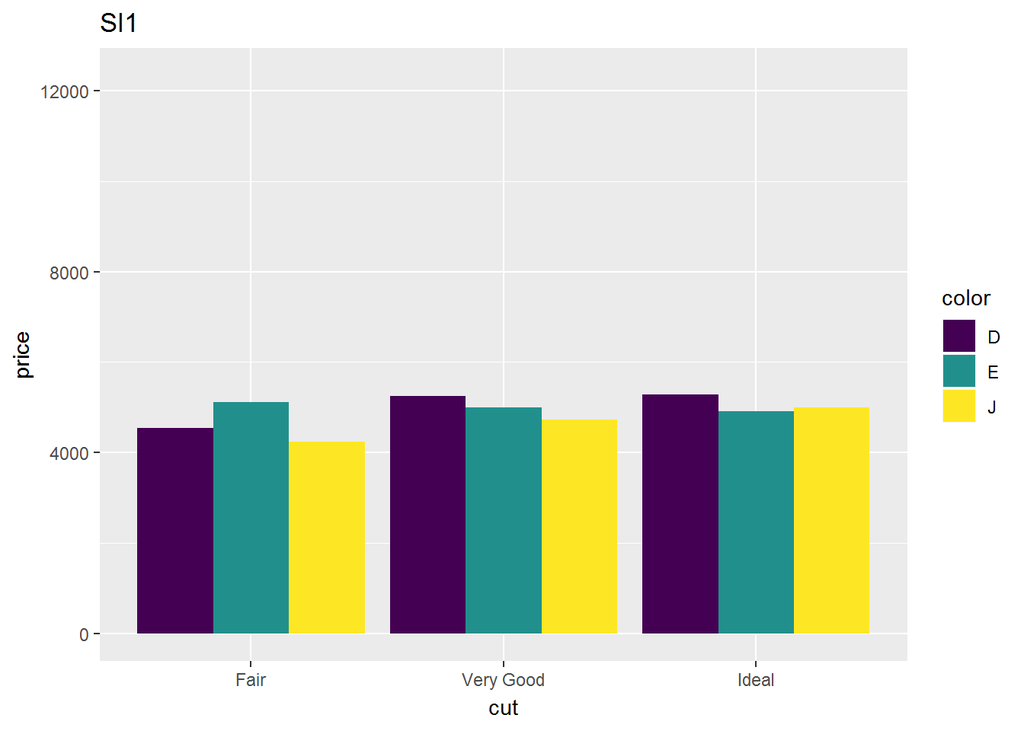

```r
diamonds_small %>%
  ggplot(aes(x = cut, y = price, fill = color)) +
  geom_bar(stat = "summary", position = "dodge") +
  labs(title = "{closest_state}") +
  transition_states(clarity)
```